# Assignment 2: Spatial Analysis and Visualization

## Part 2: Comprehensive Visualization

Using the skills from Week 3 (Data Visualization), create publication-quality maps and charts.

### Map 1: County-Level Choropleth

Create a choropleth map showing healthcare access challenges at the county level.

**Your Task:**

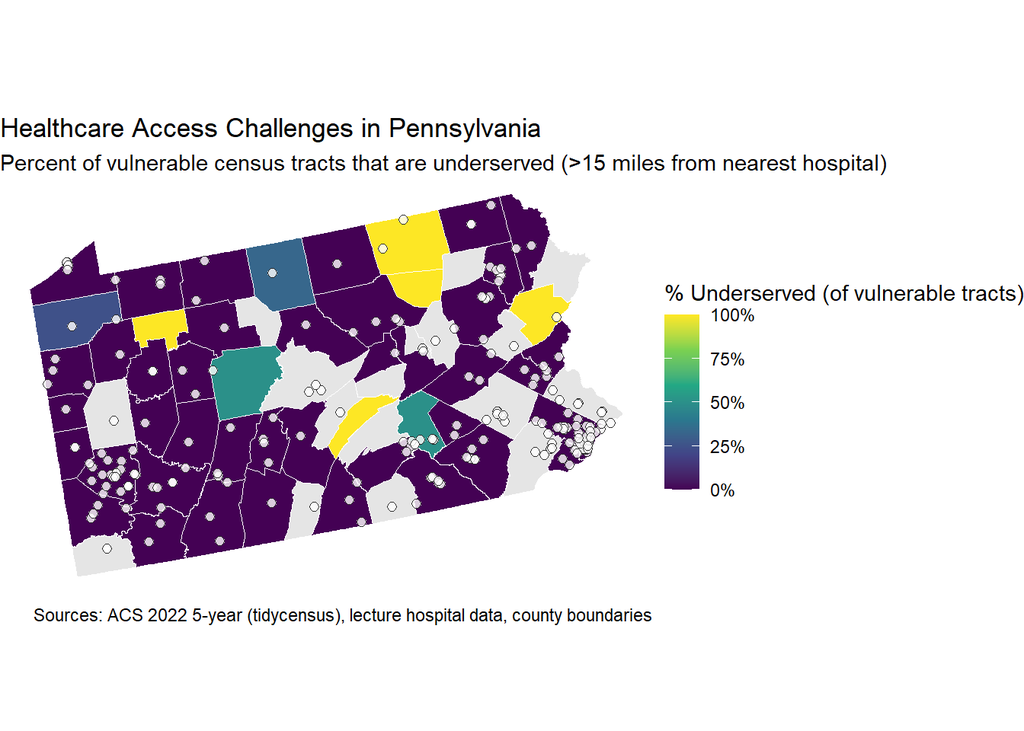

```r
# Create county-level access map
library(ggplot2)
library(scales)
library(dplyr)


pa_counties_map <- pa_counties_proj %>%
  left_join(
    priority_counties %>%
      st_drop_geometry() %>%
      select(County, `Underserved (%)`),
    by = c("COUNTY_NAM" = "County")
  )

ggplot() +
  geom_sf(
    data = pa_counties_map,
    aes(fill = `Underserved (%)`),
    color = "white", size = 0.25
  ) +
  geom_sf(
    data = hospitals,
    shape = 21, fill = "white", color = "black", size = 2, alpha = 0.8
  ) +
  scale_fill_viridis_c(
    option = "Viridis",
    name = "% Underserved (of vulnerable tracts)",
    labels = function(x) paste0(x, "%"),
    na.value = "grey90",
    limits = c(0, 100)
  ) +
  labs(
    title = "Healthcare Access Challenges in Pennsylvania",
    subtitle = "Percent of vulnerable census tracts that are underserved (>15 miles from nearest hospital)",
    caption = "Sources: ACS 2022 5-year (tidycensus), lecture hospital data, county boundaries"
  ) +
  theme_void()
```

**Requirements:** - Fill counties by percentage of vulnerable tracts that are underserved - Include hospital locations as points - Use an appropriate color scheme - Include clear title, subtitle, and caption - Use `theme_void()` or similar clean theme - Add a legend with formatted labels

### Map 2: Detailed Vulnerability Map

Create a map highlighting underserved vulnerable tracts.

**Your Task:**

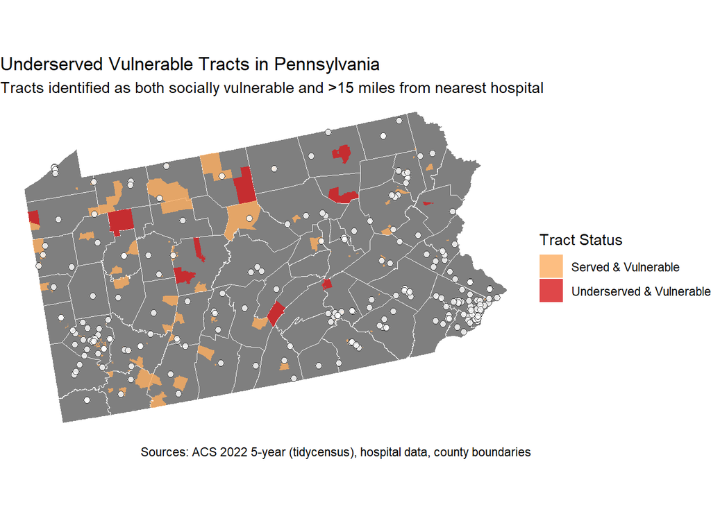

```r
# Create detailed tract-level map
vulnerable_tracts_proj <- vulnerable_tracts_proj %>%
  mutate(
    vulnerable= median_income <= income_threshold &
                elderly_share >= elderly_threshold
  ) %>%
  mutate(
    tract_status = case_when(
      vulnerable & underserved ~ "Underserved & Vulnerable",
      vulnerable & !underserved ~ "Served & Vulnerable",
      TRUE ~ "Other Tracts"
  )
)


ggplot()+
  geom_sf(data = pa_counties_proj, fill = "grey50", color = "white", size = 0.3) +
  geom_sf(
    data = vulnerable_tracts_proj,
    aes(fill = tract_status),
    color = NA,
    alpha = 0.8
  ) +
  geom_sf(
     data = hospitals, shape = 21, fill = "white", color = "black", size = 2, alpha = 0.8
  ) +
  scale_fill_manual(
    name = "Tract Status",
    values = c(
      "Underserved & Vulnerable" = "#d7191c",
      "Served & Vulnerable" = "#fdae61",
      "Other Tracts" = "#cccccc"
    )
  ) +
  labs(
    title = "Underserved Vulnerable Tracts in Pennsylvania",
    subtitle = "Tracts identified as both socially vulnerable and >15 miles from nearest hospital",
    caption = "Sources: ACS 2022 5-year (tidycensus), hospital data, county boundaries"
  ) +
  theme_void()
```

**Requirements:** - Show underserved vulnerable tracts in a contrasting color - Include county boundaries for context - Show hospital locations - Use appropriate visual hierarchy (what should stand out?) - Include informative title and subtitle

### Chart: Distribution Analysis

Create a visualization showing the distribution of distances to hospitals for vulnerable populations.

**Your Task:**

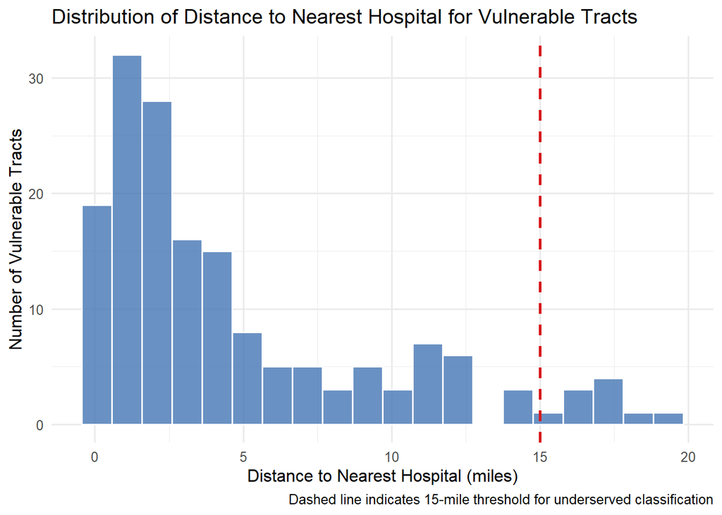

```r
# Create distribution visualization
ggplot(vulnerable_tracts_proj, aes(x = distance_to_hospital_miles)) +
  geom_histogram(bins = 20, fill = "#4575b4", color = "white", alpha = 0.8) +
  geom_vline(xintercept = 15, color = "#d7191c", linetype = "dashed", size = 1) +
  labs(
    title = "Distribution of Distance to Nearest Hospital for Vulnerable Tracts",
    x = "Distance to Nearest Hospital (miles)",
    y = "Number of Vulnerable Tracts",
    caption = "Dashed line indicates 15-mile threshold for underserved classification"
  ) +
  theme_minimal(base_size = 12)
```

**Suggested chart types:** - Histogram or density plot of distances - Box plot comparing distances across regions - Bar chart of underserved tracts by county - Scatter plot of distance vs. vulnerable population size

**Requirements:** - Clear axes labels with units - Appropriate title - Professional formatting - Brief interpretation (1-2 sentences as a caption or in text)